# Visualize temporal networks

How do network-level metrics change over time? (I have not calculated network-level metrics such as density and modularity yet–could go back and do that. For now, I’m going to use mean mean degree/mean mean strength as measures).

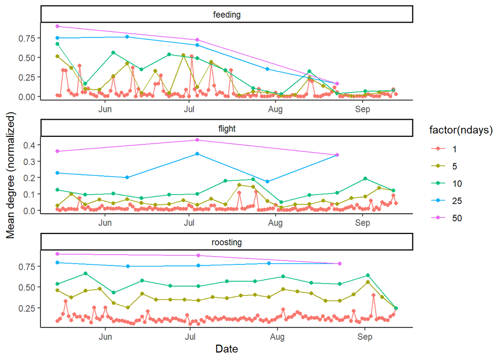

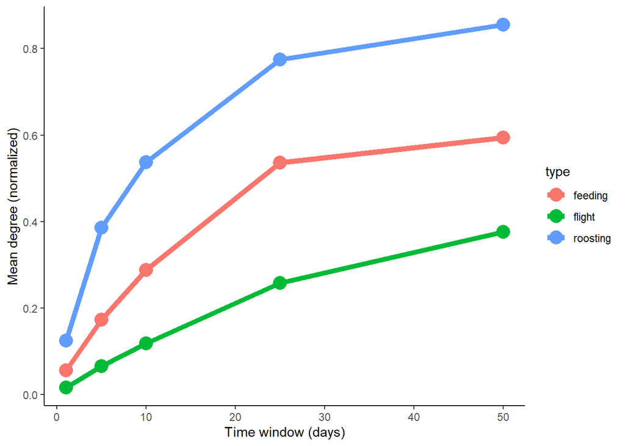

Now let’s examine how the network measures change over the time points at different scales.

Degree:

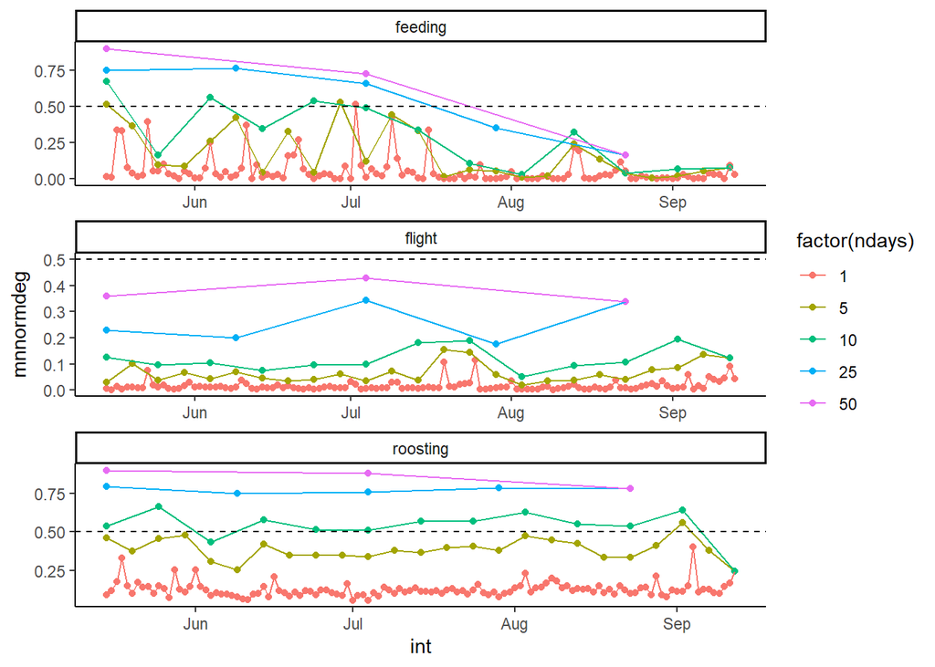

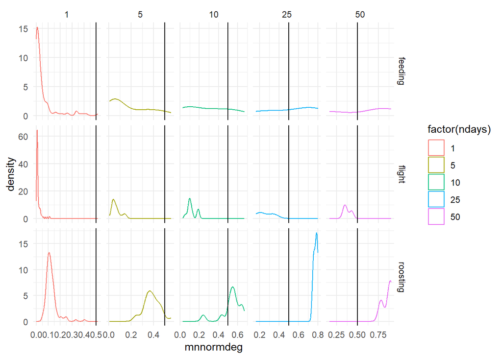

Strength:

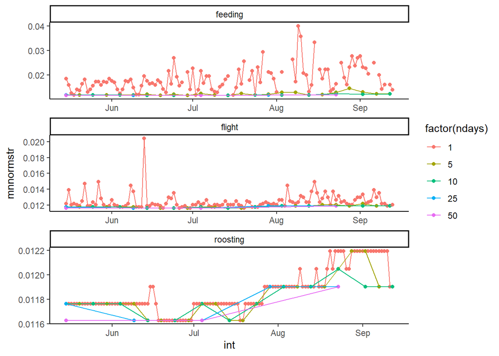

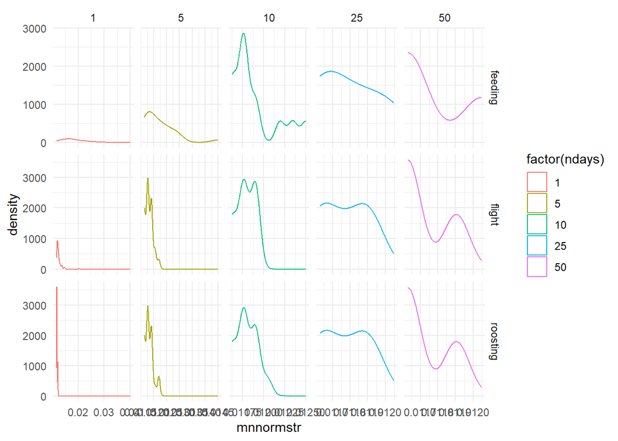

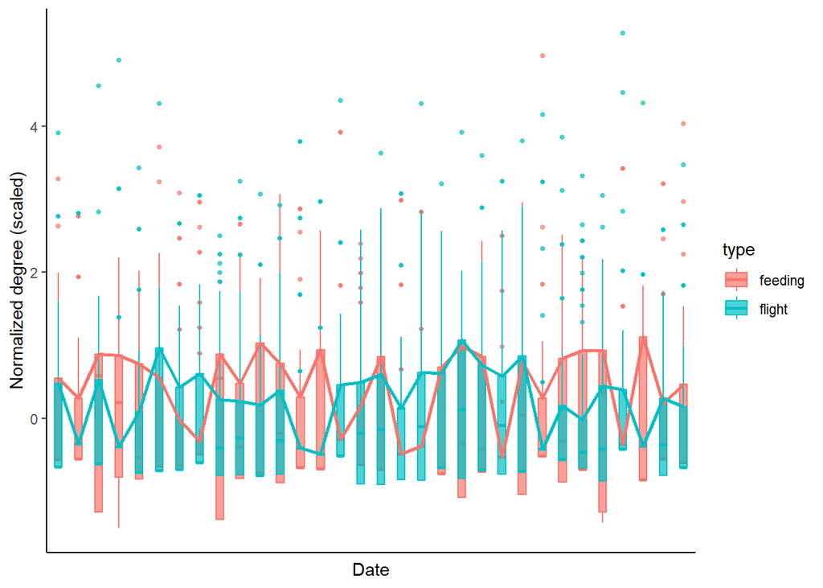

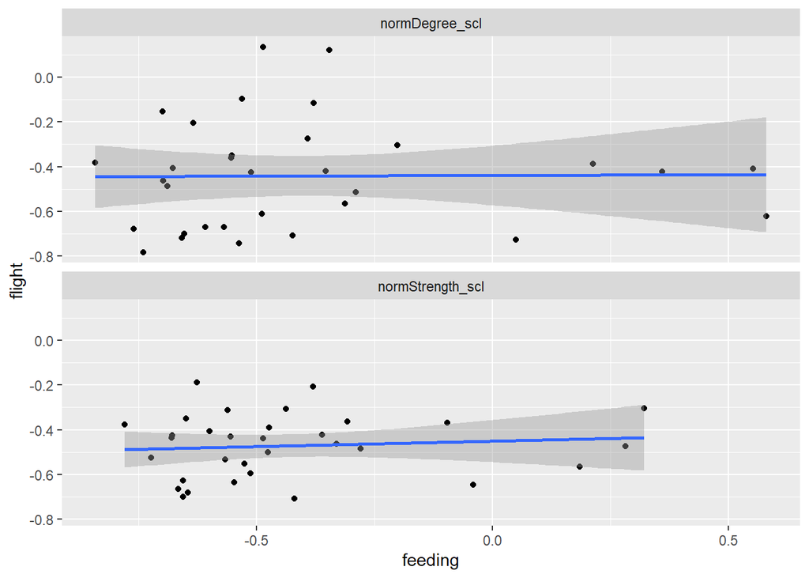

What about the number of interactions over time?

We have to go back to the edge lists (not the graphs created from them) for this.

Now make some plots

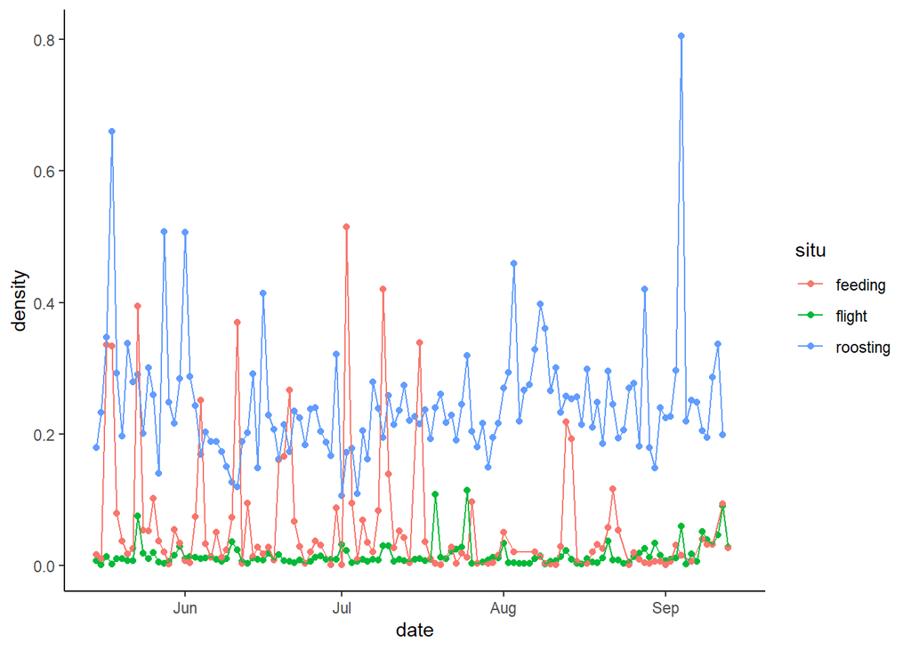

```
# A tibble: 16 x 10
   date       indivs_interacting interactions timegroups_interacting situ  edges
   <date>                  <int>        <int>                  <int> <chr> <int>
 1 2023-05-17                107         6596                     45 feed~  1034
 2 2023-05-18                141         7025                     69 feed~  1191
 3 2023-05-23                105         9558                     41 feed~  1156
 4 2023-05-26                 61          628                     31 feed~   169
 5 2023-06-04                103        11664                     52 feed~   794
 6 2023-06-11                126         9066                     52 feed~  1259
 7 2023-06-19                 63         1284                     33 feed~   276
 8 2023-06-20                 81         1579                     31 feed~   402
 9 2023-06-21                119         5261                     60 feed~   803
10 2023-07-02                148         9398                     50 feed~  1794
11 2023-07-09                119         8844                     57 feed~  1199
12 2023-07-10                 94         1815                     47 feed~   417
13 2023-07-16                141         4444                     36 feed~  1181
14 2023-08-13                 92         2938                     34 feed~   623
15 2023-08-14                 69         1537                     31 feed~   377
16 2023-08-22                 85          807                     19 feed~   282
# i 4 more variables: n_total <int>, indivs_interacting_prop <dbl>,
#   interactions_norm <dbl>, density <dbl>
```

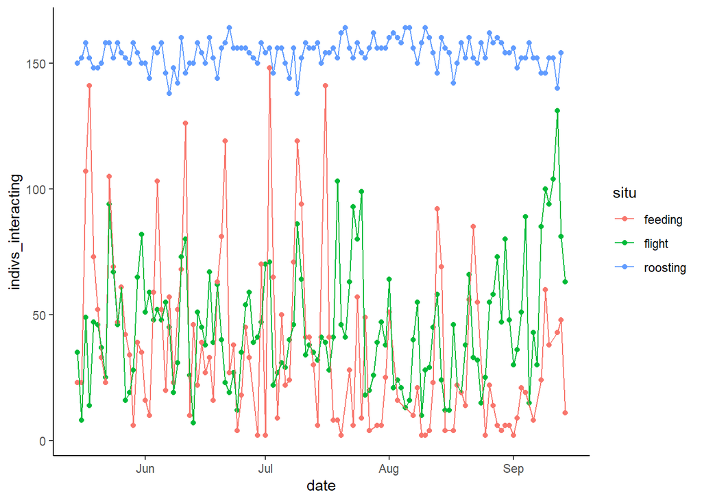

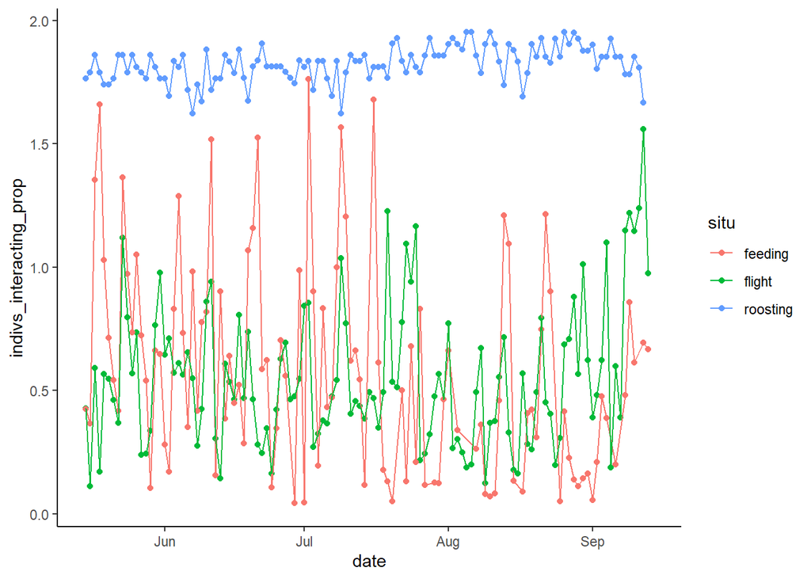

# Feeding-flight correlation

Is there a (negative? positive?) correlation between feeding and flight situations in terms of number of interactions?

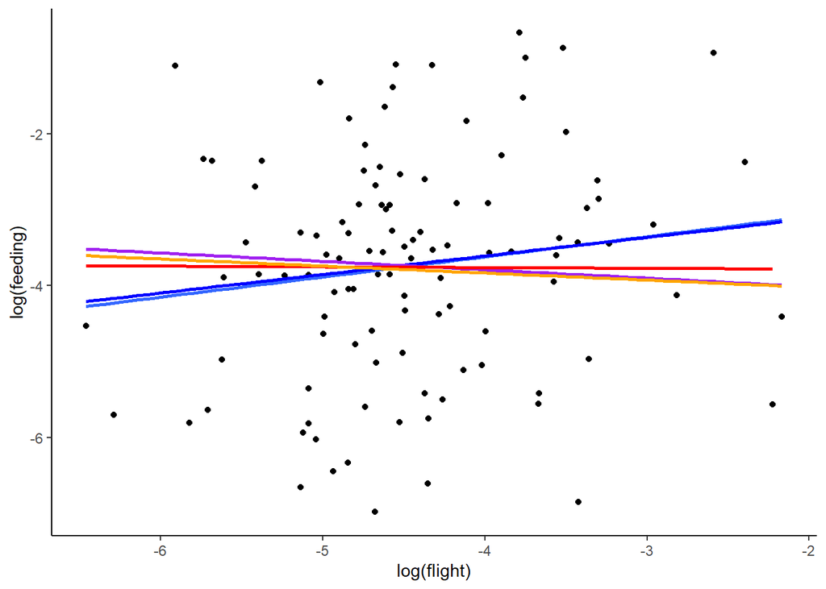

More investigation of correlation between feeding and flight metrics.

Code for rolling correlations from [here](https://www.r-bloggers.com/2017/07/tidy-time-series-analysis-part-3-the-rolling-correlation/)

[output not shown]

```
Correlation computed with
* Method: 'pearson'
* Missing treated using: 'pairwise.complete.obs'
```

```
# A tibble: 3 x 4
  term     flight feeding roosting
  <chr>     <dbl>   <dbl>    <dbl>
1 flight       NA   0.128   -0.228
2 feeding      NA  NA       -0.266
3 roosting     NA  NA       NA
```

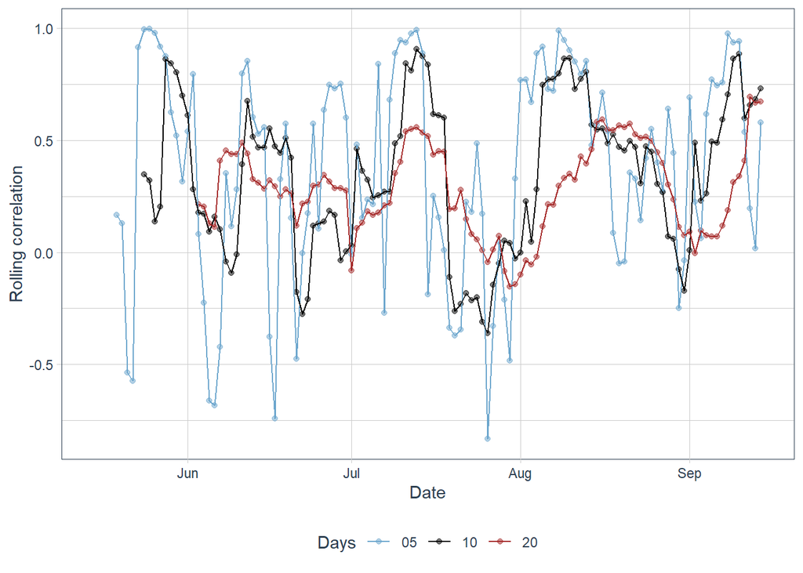